# StarCraft Player Performance Analytics Project Overview:

# Objective:

The main objective of this project was to analyze and identify key factors that influence a player's rank in the game, based on a dataset of Starcraft player performance metrics.

# Time Constraint:

The analysis was performed under a strict 5-hour deadline.

# Key Procedures:

1. Data Cleaning:
- Checked for duplicates: No duplicates found.
- Converted non-numeric values to NaN.
- Changed data types to their appropriate types (e.g., float to int).
- Checked and handled missing data: LeagueIndex 8 had missing values and was excluded from the analysis due to insufficient data.
2. Exploratory Data Analysis (EDA):
- Visualized the distribution of the target variable, 'LeagueIndex'.
- Generated scatter plots for different features against 'LeagueIndex' to understand relationships.
- Filtered outliers from features such as 'TotalHours' and 'HoursPerWeek'.
3. Feature Importance Analysis:
- Correlation matrix heatmap was plotted to observe feature relationships.
- Features were further analyzed using different models to understand their significance.
4. Model Building & Evaluation:
- Implemented various models: Logistic Regression, SVM, Ordinal Regression, Gradient Boosting, Random Forest, Neural Network, and AutoML (AutoSklearn).
- Each model's performance was assessed based on accuracy and Mean Squared Error (MSE).
- Random Forest emerged as the best model but had some concerns regarding its predictions. The model's accuracy was still low, highlighting the possibility of further improvement.
5. Conclusion & Recommendations:
- Five crucial features impacting player's rank were identified: ActionLatency, APM, TotalHours, SelectByHotkeys, and AssignToHotkeys.
- Recommendations were provided for players to focus on certain aspects to improve their game performance.
6. Additional Insights:
- Auto-Sklearn, a more resource-intensive model, was also used which provided decent performance.

# Tools & Libraries Used:

Pandas, NumPy, Matplotlib, Seaborn, Scikit-learn, Keras, AutoSklearn, and mord.

# Challenges:

Handling missing data, especially for 'LeagueIndex 8', and determining the best way to treat outliers in features like 'TotalHours' and 'HoursPerWeek'. Also, achieving a high accuracy with the models proved challenging.

# Value Delivered:

The project provided a comprehensive understanding of the key factors influencing a player's rank in Starcraft. The recommendations can help players understand where to focus their efforts for improvement.

# Further Exploration:

The analysis suggests that better feature engineering or using MSE as an evaluation metric might yield improved results. There's also potential to explore other advanced modeling techniques or gather more data to enhance the predictions.

```python
#Importing necessary libraries for analysis
import numpy as np
import pandas as pd
import matplotlib.pyplot as plt
import seaborn as sns
from sklearn.model_selection import train_test_split
from sklearn.preprocessing import StandardScaler
from sklearn.linear_model import LogisticRegression
import autosklearn.regression
import autosklearn.metrics
from sklearn.metrics import mean_squared_error
from sklearn.inspection import permutation_importance
from keras.models import Sequential
from keras.layers import Dense
from sklearn.ensemble import RandomForestRegressor
from sklearn.ensemble import GradientBoostingClassifier
from mord import LogisticAT
from sklearn.svm import SVC
from sklearn.metrics import classification_report, accuracy_score
from sklearn.impute import SimpleImputer
```

```python
df = pd.read_csv("starcraft_player_data.csv")
```

```python
df.head()
```

|  | GameID | LeagueIndex | Age | HoursPerWeek | TotalHours | APM | SelectByHotkeys | AssignToHotkeys | UniqueHotkeys | MinimapAttacks | MinimapRightClicks | NumberOfPACs | GapBetweenPACs | ActionLatency | ActionsInPAC | TotalMapExplored | WorkersMade | UniqueUnitsMade | ComplexUnitsMade | ComplexAbilitiesUsed |
| --- | --- | --- | --- | --- | --- | --- | --- | --- | --- | --- | --- | --- | --- | --- | --- | --- | --- | --- | --- | --- |
| 0 | 52 | 5 | 27 | 10 | 3000 | 143.7180 | 0.003515 | 0.000220 | 7 | 0.000110 | 0.000392 | 0.004849 | 32.6677 | 40.8673 | 4.7508 | 28 | 0.001397 | 6 | 0.0 | 0.000000 |
| 1 | 55 | 5 | 23 | 10 | 5000 | 129.2322 | 0.003304 | 0.000259 | 4 | 0.000294 | 0.000432 | 0.004307 | 32.9194 | 42.3454 | 4.8434 | 22 | 0.001193 | 5 | 0.0 | 0.000208 |
| 2 | 56 | 4 | 30 | 10 | 200 | 69.9612 | 0.001101 | 0.000336 | 4 | 0.000294 | 0.000461 | 0.002926 | 44.6475 | 75.3548 | 4.0430 | 22 | 0.000745 | 6 | 0.0 | 0.000189 |
| 3 | 57 | 3 | 19 | 20 | 400 | 107.6016 | 0.001034 | 0.000213 | 1 | 0.000053 | 0.000543 | 0.003783 | 29.2203 | 53.7352 | 4.9155 | 19 | 0.000426 | 7 | 0.0 | 0.000384 |
| 4 | 58 | 3 | 32 | 10 | 500 | 122.8908 | 0.001136 | 0.000327 | 2 | 0.000000 | 0.001329 | 0.002368 | 22.6885 | 62.0813 | 9.3740 | 15 | 0.001174 | 4 | 0.0 | 0.000019 |

```python
# Check the data types of each column
print(df.dtypes)

# Check for missing values
print(df.isnull().sum())
```

```
GameID                    int64
LeagueIndex               int64
Age                      object
HoursPerWeek             object
TotalHours               object
APM                     float64
SelectByHotkeys         float64
AssignToHotkeys         float64
UniqueHotkeys             int64
MinimapAttacks          float64
MinimapRightClicks      float64
NumberOfPACs            float64
GapBetweenPACs          float64
ActionLatency           float64
ActionsInPAC            float64
TotalMapExplored          int64
WorkersMade             float64
UniqueUnitsMade           int64
ComplexUnitsMade        float64
ComplexAbilitiesUsed    float64
dtype: object
GameID                  0
LeagueIndex             0
Age                     0
HoursPerWeek            0
TotalHours              0
APM                     0
SelectByHotkeys         0
AssignToHotkeys         0
UniqueHotkeys           0
MinimapAttacks          0
MinimapRightClicks      0
NumberOfPACs            0
GapBetweenPACs          0
ActionLatency           0
ActionsInPAC            0
TotalMapExplored        0
WorkersMade             0
UniqueUnitsMade         0
ComplexUnitsMade        0
ComplexAbilitiesUsed    0
dtype: int64
```

```python
# Assuming your DataFrame is named 'df'
duplicates = df.duplicated()

if duplicates.any():
    print("Duplicates found in the DataFrame.")
    # To see the duplicated rows, you can use:
    # duplicated_rows = df[duplicates]
else:
    print("No duplicates found in the DataFrame.")
```

```
No duplicates found in the DataFrame.
```

```python
# Replace non-numeric values with NaN
df['Age'] = pd.to_numeric(df['Age'], errors='coerce')
df['HoursPerWeek'] = pd.to_numeric(df['HoursPerWeek'], errors='coerce')
df['TotalHours'] = pd.to_numeric(df['TotalHours'], errors='coerce')

# Convert Age, HoursPerWeek, and TotalHours to integer
df['Age'] = df['Age'].astype('Int64')
df['HoursPerWeek'] = df['HoursPerWeek'].astype('Int64')
df['TotalHours'] = df['TotalHours'].astype('Int64')

# Convert TotalMapExplored to float
df['TotalMapExplored'] = df['TotalMapExplored'].astype(float)
```

```python
# Check the data types of each column
print(df.dtypes)

# Check for missing values
print(df.isnull().sum())
```

```
GameID                    int64
LeagueIndex               int64
Age                       Int64
HoursPerWeek              Int64
TotalHours                Int64
APM                     float64
SelectByHotkeys         float64
AssignToHotkeys         float64
UniqueHotkeys             int64
MinimapAttacks          float64
MinimapRightClicks      float64
NumberOfPACs            float64
GapBetweenPACs          float64
ActionLatency           float64
ActionsInPAC            float64
TotalMapExplored        float64
WorkersMade             float64
UniqueUnitsMade           int64
ComplexUnitsMade        float64
ComplexAbilitiesUsed    float64
dtype: object
GameID                   0
LeagueIndex              0
Age                     55
HoursPerWeek            56
TotalHours              57
APM                      0
SelectByHotkeys          0
AssignToHotkeys          0
UniqueHotkeys            0
MinimapAttacks           0
MinimapRightClicks       0
NumberOfPACs             0
GapBetweenPACs           0
ActionLatency            0
ActionsInPAC             0
TotalMapExplored         0
WorkersMade              0
UniqueUnitsMade          0
ComplexUnitsMade         0
ComplexAbilitiesUsed     0
dtype: int64
```

```python
#identify which LeaugeIndex had the null values
filtered_df1 = df[(df['LeagueIndex'] == 8) & (df['Age'].notnull())]
print(filtered_df1)
```

```
Empty DataFrame
Columns: [GameID, LeagueIndex, Age, HoursPerWeek, TotalHours, APM, SelectByHotkeys, AssignToHotkeys, UniqueHotkeys, MinimapAttacks, MinimapRightClicks, NumberOfPACs, GapBetweenPACs, ActionLatency, ActionsInPAC, TotalMapExplored, WorkersMade, UniqueUnitsMade, ComplexUnitsMade, ComplexAbilitiesUsed]
Index: []
```

```python
# Finding rows with missing data in column 'TotalHours' and that is not leagueindex=8
mask = df['TotalHours'].isna()
rows_with_missing_data = df.loc[mask]

# Accessing values of other columns for the selected rows
other_columns_values = rows_with_missing_data[['LeagueIndex', 'APM']]

print(other_columns_values.head())
```

```
      LeagueIndex       APM
358             5   94.4724
1841            5  122.2470
3340            8  189.7404
3341            8  287.8128
3342            8  294.0996
```

# Justification:

Considering the limited time I had, I made the decision to exclude LeagueIndex = 8 from the analysis. The reason behind this was that there wasn't enough available data to support using statistical measures like mean, median, or sampling. While it would have been possible to use regression techniques to populate the missing data for this class, unfortunately, time constraints prevented me from doing so.

```python
filtered_df = df.dropna(subset=['TotalHours'])

filtered_df
```

|  | GameID | LeagueIndex | Age | HoursPerWeek | TotalHours | APM | SelectByHotkeys | AssignToHotkeys | UniqueHotkeys | MinimapAttacks | MinimapRightClicks | NumberOfPACs | GapBetweenPACs | ActionLatency | ActionsInPAC | TotalMapExplored | WorkersMade | UniqueUnitsMade | ComplexUnitsMade | ComplexAbilitiesUsed |
| --- | --- | --- | --- | --- | --- | --- | --- | --- | --- | --- | --- | --- | --- | --- | --- | --- | --- | --- | --- | --- |
| 0 | 52 | 5 | 27 | 10 | 3000 | 143.7180 | 0.003515 | 0.000220 | 7 | 0.000110 | 0.000392 | 0.004849 | 32.6677 | 40.8673 | 4.7508 | 28.0 | 0.001397 | 6 | 0.0 | 0.000000 |
| 1 | 55 | 5 | 23 | 10 | 5000 | 129.2322 | 0.003304 | 0.000259 | 4 | 0.000294 | 0.000432 | 0.004307 | 32.9194 | 42.3454 | 4.8434 | 22.0 | 0.001193 | 5 | 0.0 | 0.000208 |
| 2 | 56 | 4 | 30 | 10 | 200 | 69.9612 | 0.001101 | 0.000336 | 4 | 0.000294 | 0.000461 | 0.002926 | 44.6475 | 75.3548 | 4.0430 | 22.0 | 0.000745 | 6 | 0.0 | 0.000189 |
| 3 | 57 | 3 | 19 | 20 | 400 | 107.6016 | 0.001034 | 0.000213 | 1 | 0.000053 | 0.000543 | 0.003783 | 29.2203 | 53.7352 | 4.9155 | 19.0 | 0.000426 | 7 | 0.0 | 0.000384 |
| 4 | 58 | 3 | 32 | 10 | 500 | 122.8908 | 0.001136 | 0.000327 | 2 | 0.000000 | 0.001329 | 0.002368 | 22.6885 | 62.0813 | 9.3740 | 15.0 | 0.001174 | 4 | 0.0 | 0.000019 |
| ... | ... | ... | ... | ... | ... | ... | ... | ... | ... | ... | ... | ... | ... | ... | ... | ... | ... | ... | ... | ... |
| 3335 | 9261 | 4 | 20 | 8 | 400 | 158.1390 | 0.013829 | 0.000504 | 7 | 0.000217 | 0.000313 | 0.003583 | 36.3990 | 66.2718 | 4.5097 | 30.0 | 0.001035 | 7 | 0.0 | 0.000287 |
| 3336 | 9264 | 5 | 16 | 56 | 1500 | 186.1320 | 0.006951 | 0.000360 | 6 | 0.000083 | 0.000166 | 0.005414 | 22.8615 | 34.7417 | 4.9309 | 38.0 | 0.001343 | 7 | 0.0 | 0.000388 |
| 3337 | 9265 | 4 | 21 | 8 | 100 | 121.6992 | 0.002956 | 0.000241 | 8 | 0.000055 | 0.000208 | 0.003690 | 35.5833 | 57.9585 | 5.4154 | 23.0 | 0.002014 | 7 | 0.0 | 0.000000 |
| 3338 | 9270 | 3 | 20 | 28 | 400 | 134.2848 | 0.005424 | 0.000182 | 5 | 0.000000 | 0.000480 | 0.003205 | 18.2927 | 62.4615 | 6.0202 | 18.0 | 0.000934 | 5 | 0.0 | 0.000000 |
| 3339 | 9271 | 4 | 22 | 6 | 400 | 88.8246 | 0.000844 | 0.000108 | 2 | 0.000000 | 0.000341 | 0.003099 | 45.1512 | 63.4435 | 5.1913 | 20.0 | 0.000476 | 8 | 0.0 | 0.000054 |

3338 rows × 20 columns

```python
# Finding rows with missing data in column 'TotalHours'
mask = filtered_df['TotalHours'].isna()
rows_with_missing_data = filtered_df.loc[mask]

# Accessing values of other columns for the selected rows
other_columns_values = rows_with_missing_data[['LeagueIndex', 'APM']]

print(other_columns_values.head())

# Check for missing values
print(filtered_df.isnull().sum())
```

```
Empty DataFrame
Columns: [LeagueIndex, APM]
Index: []
GameID                  0
LeagueIndex             0
Age                     0
HoursPerWeek            0
TotalHours              0
APM                     0
SelectByHotkeys         0
AssignToHotkeys         0
UniqueHotkeys           0
MinimapAttacks          0
MinimapRightClicks      0
NumberOfPACs            0
GapBetweenPACs          0
ActionLatency           0
ActionsInPAC            0
TotalMapExplored        0
WorkersMade             0
UniqueUnitsMade         0
ComplexUnitsMade        0
ComplexAbilitiesUsed    0
dtype: int64
```

```python
filtered_df.describe()
```

|  | GameID | LeagueIndex | Age | HoursPerWeek | TotalHours | APM | SelectByHotkeys | AssignToHotkeys | UniqueHotkeys | MinimapAttacks | MinimapRightClicks | NumberOfPACs | GapBetweenPACs | ActionLatency | ActionsInPAC | TotalMapExplored | WorkersMade | UniqueUnitsMade | ComplexUnitsMade | ComplexAbilitiesUsed |
| --- | --- | --- | --- | --- | --- | --- | --- | --- | --- | --- | --- | --- | --- | --- | --- | --- | --- | --- | --- | --- |
| count | 3338.000000 | 3338.000000 | 3338.0 | 3338.0 | 3338.0 | 3338.000000 | 3338.000000 | 3338.000000 | 3338.000000 | 3338.000000 | 3338.000000 | 3338.000000 | 3338.000000 | 3338.000000 | 3338.000000 | 3338.000000 | 3338.000000 | 3338.000000 | 3338.000000 | 3338.000000 |
| mean | 4719.552127 | 4.120731 | 21.650389 | 15.909527 | 960.421809 | 114.575763 | 0.004023 | 0.000364 | 4.316357 | 0.000094 | 0.000380 | 0.003433 | 40.713819 | 64.209584 | 5.266955 | 22.116836 | 0.001031 | 6.541043 | 0.000060 | 0.000142 |
| std | 2656.919630 | 1.448170 | 4.206357 | 11.964495 | 17318.133922 | 48.111912 | 0.004726 | 0.000210 | 2.333322 | 0.000159 | 0.000359 | 0.000966 | 17.057191 | 19.037394 | 1.500605 | 7.440875 | 0.000520 | 1.859049 | 0.000112 | 0.000266 |
| min | 52.000000 | 1.000000 | 16.0 | 0.0 | 3.0 | 22.059600 | 0.000000 | 0.000000 | 0.000000 | 0.000000 | 0.000000 | 0.000679 | 6.666700 | 24.632600 | 2.038900 | 5.000000 | 0.000077 | 2.000000 | 0.000000 | 0.000000 |
| 25% | 2423.250000 | 3.000000 | 19.0 | 8.0 | 300.0 | 79.231500 | 0.001245 | 0.000202 | 3.000000 | 0.000000 | 0.000139 | 0.002743 | 29.326600 | 50.886425 | 4.261525 | 17.000000 | 0.000682 | 5.000000 | 0.000000 | 0.000000 |
| 50% | 4788.000000 | 4.000000 | 21.0 | 12.0 | 500.0 | 107.070300 | 0.002445 | 0.000349 | 4.000000 | 0.000039 | 0.000278 | 0.003376 | 37.058900 | 61.296100 | 5.087050 | 22.000000 | 0.000904 | 6.000000 | 0.000000 | 0.000020 |
| 75% | 6994.750000 | 5.000000 | 24.0 | 20.0 | 800.0 | 140.156100 | 0.004945 | 0.000493 | 6.000000 | 0.000113 | 0.000508 | 0.004003 | 48.510425 | 74.032525 | 6.027350 | 27.000000 | 0.001258 | 8.000000 | 0.000087 | 0.000182 |
| max | 9271.000000 | 7.000000 | 44.0 | 168.0 | 1000000.0 | 389.831400 | 0.043088 | 0.001648 | 10.000000 | 0.003019 | 0.003688 | 0.007971 | 237.142900 | 176.372100 | 18.558100 | 58.000000 | 0.005149 | 13.000000 | 0.000902 | 0.003084 |

```python
# Check for missing values
print(filtered_df.isnull().sum())
```

```
GameID                  0
LeagueIndex             0
Age                     0
HoursPerWeek            0
TotalHours              0
APM                     0
SelectByHotkeys         0
AssignToHotkeys         0
UniqueHotkeys           0
MinimapAttacks          0
MinimapRightClicks      0
NumberOfPACs            0
GapBetweenPACs          0
ActionLatency           0
ActionsInPAC            0
TotalMapExplored        0
WorkersMade             0
UniqueUnitsMade         0
ComplexUnitsMade        0
ComplexAbilitiesUsed    0
dtype: int64
```

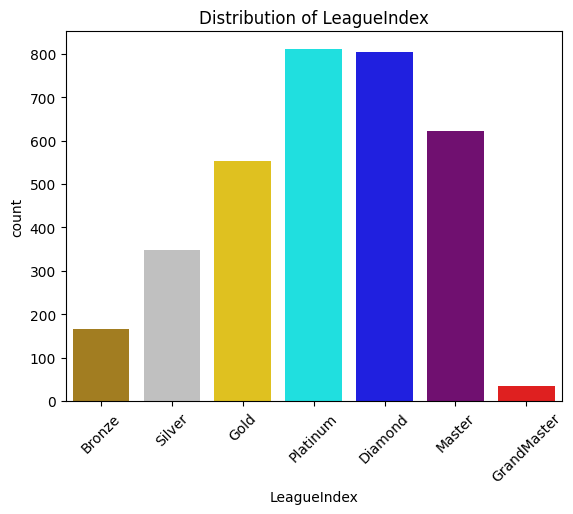

```python
# Define the league_labels dictionary
league_labels = {
    1: 'Bronze',
    2: 'Silver',
    3: 'Gold',
    4: 'Platinum',
    5: 'Diamond',
    6: 'Master',
    7: 'GrandMaster'
}

# Define the colors for each league
colors = ['darkgoldenrod', 'silver', 'gold', 'cyan', 'blue', 'purple', 'red', 'black']

# Visualize the distribution of the target variable (LeagueIndex)
sns.countplot(x='LeagueIndex', data=filtered_df, palette=colors)
plt.title('Distribution of LeagueIndex')
plt.xticks(ticks=np.arange(7), labels=[league_labels[i] for i in range(1, 8)], rotation=45)  # Set custom x-axis labels and rotate them
plt.show()
```

```python
def scatter_plot(data_frame, x_column, y_column, x_label, y_label):
    plt.scatter(data_frame[x_column], data_frame[y_column])
    plt.xlabel(x_label)
    plt.ylabel(y_label)
    plt.show()
```

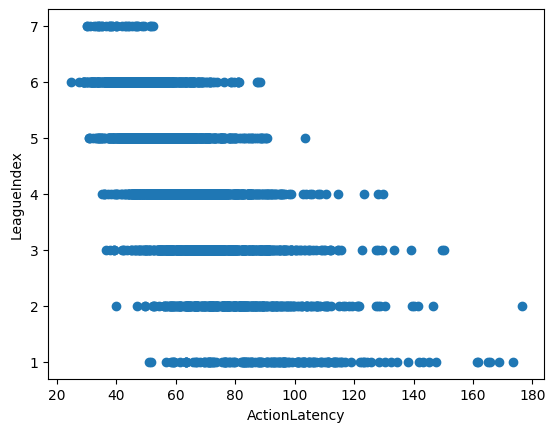

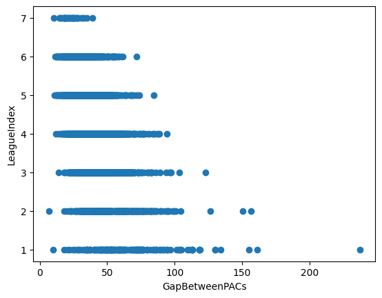

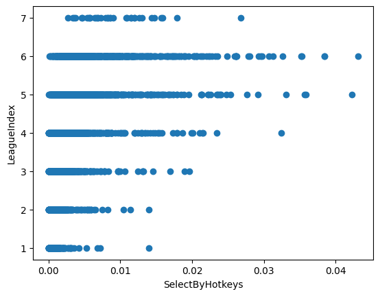

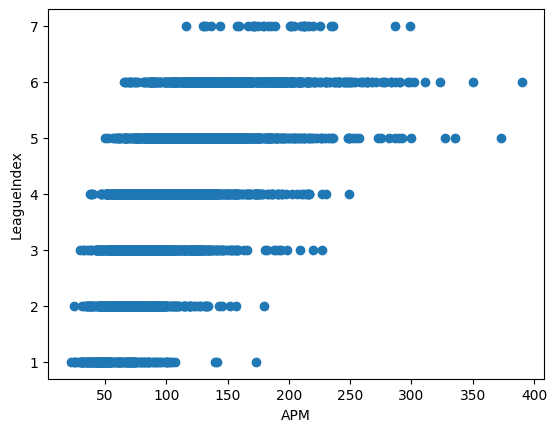

```python
scatter_plot(filtered_df, 'ActionLatency', 'LeagueIndex', 'ActionLatency', 'LeagueIndex')
scatter_plot(filtered_df, 'GapBetweenPACs', 'LeagueIndex', 'GapBetweenPACs', 'LeagueIndex')
scatter_plot(filtered_df, 'SelectByHotkeys', 'LeagueIndex', 'SelectByHotkeys', 'LeagueIndex')
scatter_plot(filtered_df, 'APM', 'LeagueIndex', 'APM', 'LeagueIndex')
```

The scatter plots above are logically sound, requiring no changes. A player with high Action latency (180) can be ranked in Silver, indicating their superior game knowledge or builds compared to players in Bronze.

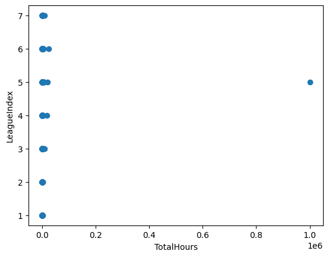

```python
# Scatter plot: TotalHours vs LeagueIndex
scatter_plot(filtered_df, 'TotalHours', 'LeagueIndex', 'TotalHours', 'LeagueIndex')
```

```python
min_hours = filtered_df['TotalHours'].min()
max_hours = filtered_df['TotalHours'].max()
print(min_hours)
print(max_hours)
```

```
3
1000000
```

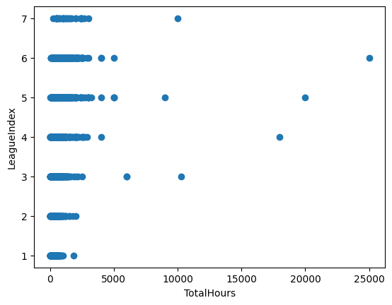

```python
##Both methods work, but I decided to just filter out the one data point

# # Calculate mean and standard deviation for TotalHours column
# mean = filtered_df['TotalHours'].mean()
# std = filtered_df['TotalHours'].std()

# # Calculate Z-scores manually
# z_scores = (filtered_df['TotalHours'] - mean) / std

# # Define a threshold (e.g., Z-score > 3 or Z-score < -3) to identify outliers
# threshold = 3

# # Filter out rows with TotalHours Z-scores beyond the threshold
# filtered_df = filtered_df[abs(z_scores) <= threshold]

# Remove the data point with TotalHours = 1000000
filtered_df = filtered_df[filtered_df['TotalHours'] != 1000000]


# Scatter plot: TotalHours vs LeagueIndex
scatter_plot(filtered_df, 'TotalHours', 'LeagueIndex', 'TotalHours', 'LeagueIndex')
```

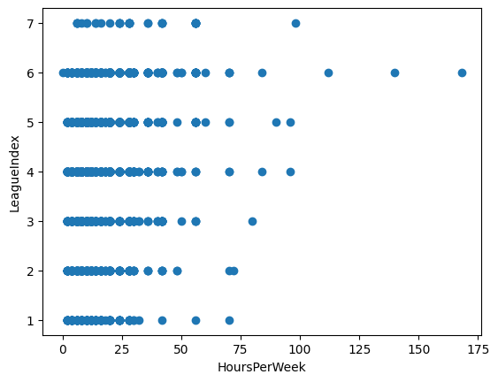

```python
scatter_plot(filtered_df, 'HoursPerWeek', 'LeagueIndex', 'HoursPerWeek', 'LeagueIndex')
```

### Removing the outlier of 168 hours, as playing every hour for the entire week is impossible.

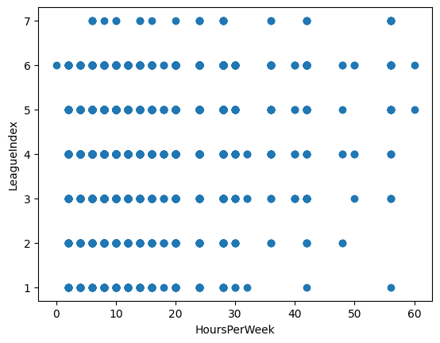

```python
# Calculate mean and standard deviation for TotalHours column
mean = filtered_df['HoursPerWeek'].mean()
std = filtered_df['HoursPerWeek'].std()

# Calculate Z-scores manually
z_scores = (filtered_df['HoursPerWeek'] - mean) / std

# Define a threshold (e.g., Z-score > 4 or Z-score < -4) to identify outliers
threshold = 4

# Filter out rows with TotalHours Z-scores beyond the threshold
filtered_df = filtered_df[abs(z_scores) <= threshold]

scatter_plot(filtered_df, 'HoursPerWeek', 'LeagueIndex', 'HoursPerWeek', 'LeagueIndex')
```

## Justification:

It is conceivable for a dedicated player to spend 60 hours a week playing. However, it should be noted that there were several outliers in the dataset, and to ensure data integrity, a cutoff at 60 hours per week was applied during the filtering process. The scatter plots above provide supporting evidence for this scenario.

```python
filtered_df.describe()
```

|  | GameID | LeagueIndex | Age | HoursPerWeek | TotalHours | APM | SelectByHotkeys | AssignToHotkeys | UniqueHotkeys | MinimapAttacks | MinimapRightClicks | NumberOfPACs | GapBetweenPACs | ActionLatency | ActionsInPAC | TotalMapExplored | WorkersMade | UniqueUnitsMade | ComplexUnitsMade | ComplexAbilitiesUsed |
| --- | --- | --- | --- | --- | --- | --- | --- | --- | --- | --- | --- | --- | --- | --- | --- | --- | --- | --- | --- | --- |
| count | 3317.000000 | 3317.000000 | 3317.0 | 3317.0 | 3317.0 | 3317.000000 | 3317.000000 | 3317.000000 | 3317.000000 | 3317.000000 | 3317.000000 | 3317.000000 | 3317.000000 | 3317.000000 | 3317.000000 | 3317.000000 | 3317.000000 | 3317.000000 | 3317.000000 | 3317.000000 |
| mean | 4724.613205 | 4.117275 | 21.662044 | 15.47543 | 657.836599 | 114.345070 | 0.003997 | 0.000363 | 4.312632 | 0.000094 | 0.000380 | 0.003430 | 40.751773 | 64.252026 | 5.266317 | 22.102804 | 0.001031 | 6.538137 | 0.000060 | 0.000141 |
| std | 2658.554774 | 1.446824 | 4.201145 | 10.438505 | 855.812321 | 47.855465 | 0.004683 | 0.000209 | 2.328354 | 0.000159 | 0.000359 | 0.000963 | 17.086203 | 19.010722 | 1.502072 | 7.423148 | 0.000521 | 1.856299 | 0.000111 | 0.000265 |
| min | 52.000000 | 1.000000 | 16.0 | 0.0 | 3.0 | 22.059600 | 0.000000 | 0.000000 | 0.000000 | 0.000000 | 0.000000 | 0.000679 | 6.666700 | 24.632600 | 2.038900 | 5.000000 | 0.000077 | 2.000000 | 0.000000 | 0.000000 |
| 25% | 2424.000000 | 3.000000 | 19.0 | 8.0 | 300.0 | 79.128000 | 0.001242 | 0.000202 | 3.000000 | 0.000000 | 0.000139 | 0.002743 | 29.343500 | 50.961200 | 4.261500 | 17.000000 | 0.000681 | 5.000000 | 0.000000 | 0.000000 |
| 50% | 4801.000000 | 4.000000 | 21.0 | 12.0 | 500.0 | 107.041200 | 0.002428 | 0.000348 | 4.000000 | 0.000039 | 0.000279 | 0.003373 | 37.094300 | 61.321400 | 5.084500 | 22.000000 | 0.000904 | 6.000000 | 0.000000 | 0.000020 |
| 75% | 6997.000000 | 5.000000 | 24.0 | 20.0 | 800.0 | 139.926600 | 0.004907 | 0.000492 | 6.000000 | 0.000112 | 0.000508 | 0.003998 | 48.564300 | 74.062500 | 6.027500 | 27.000000 | 0.001258 | 8.000000 | 0.000087 | 0.000181 |
| max | 9271.000000 | 7.000000 | 44.0 | 60.0 | 25000.0 | 389.831400 | 0.043088 | 0.001648 | 10.000000 | 0.003019 | 0.003688 | 0.007971 | 237.142900 | 176.372100 | 18.558100 | 58.000000 | 0.005149 | 13.000000 | 0.000902 | 0.003084 |

```python
# scatter_plot(filtered_df, 'Age', 'LeagueIndex', 'Age', 'LeagueIndex')
# scatter_plot(filtered_df, 'HoursPerWeek', 'LeagueIndex', 'HoursPerWeek', 'LeagueIndex')
# scatter_plot(filtered_df, 'TotalHours', 'LeagueIndex', 'TotalHours', 'LeagueIndex')
# scatter_plot(filtered_df, 'APM', 'LeagueIndex', 'APM', 'LeagueIndex')
# scatter_plot(filtered_df, 'SelectByHotkeys', 'LeagueIndex', 'SelectByHotkeys', 'LeagueIndex')
# scatter_plot(filtered_df, 'AssignToHotkeys', 'LeagueIndex', 'AssignToHotkeys', 'LeagueIndex')
# scatter_plot(filtered_df, 'UniqueHotkeys', 'LeagueIndex', 'UniqueHotkeys', 'LeagueIndex')
# scatter_plot(filtered_df, 'MinimapAttacks', 'LeagueIndex', 'MinimapAttacks', 'LeagueIndex')
# scatter_plot(filtered_df, 'MinimapRightClicks', 'LeagueIndex', 'MinimapRightClicks', 'LeagueIndex')
# scatter_plot(filtered_df, 'NumberOfPACs', 'LeagueIndex', 'NumberOfPACs', 'LeagueIndex')
# scatter_plot(filtered_df, 'GapBetweenPACs', 'LeagueIndex', 'GapBetweenPACs', 'LeagueIndex')
# scatter_plot(filtered_df, 'ActionLatency', 'LeagueIndex', 'ActionLatency', 'LeagueIndex')
# scatter_plot(filtered_df, 'ActionsInPAC', 'LeagueIndex', 'ActionsInPAC', 'LeagueIndex')
# scatter_plot(filtered_df, 'TotalMapExplored', 'LeagueIndex', 'TotalMapExplored', 'LeagueIndex')
# scatter_plot(filtered_df, 'WorkersMade', 'LeagueIndex', 'WorkersMade', 'LeagueIndex')
# scatter_plot(filtered_df, 'UniqueUnitsMade', 'LeagueIndex', 'UniqueUnitsMade', 'LeagueIndex')
# scatter_plot(filtered_df, 'ComplexUnitsMade', 'LeagueIndex', 'ComplexUnitsMade', 'LeagueIndex')
# scatter_plot(filtered_df, 'ComplexAbilitiesUsed', 'LeagueIndex', 'ComplexAbilitiesUsed', 'LeagueIndex')
```

Everything appears normal.

```python
def plot_grouped_data(data_frame, group_column, value_column, labels, colors, title, x_label, y_label):
    # Group the data and calculate the mean
    grouped_data = data_frame.groupby(group_column)[value_column].mean()

    # Plot the grouped data with custom colors
    plt.bar(grouped_data.index, grouped_data, color=colors)

    # Add custom labels to the x-axis ticks
    plt.xticks(list(labels.keys()), list(labels.values()), rotation=45)

    # Set the x-axis label, y-axis label, and plot title
    plt.xlabel(x_label)
    plt.ylabel(y_label)
    plt.title(title)

    plt.show()
```

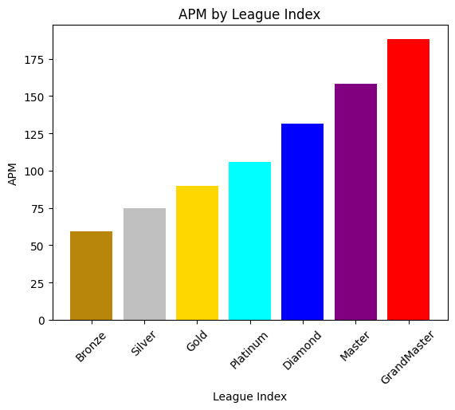

```python
#Call plot grouped data function for total hours
plot_grouped_data(filtered_df, 'LeagueIndex', 'APM', league_labels, colors, 'APM by League Index', 'League Index', 'APM')
```

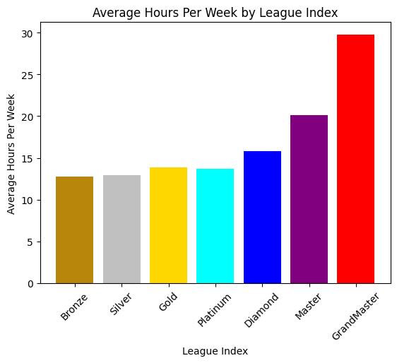

```python
#Call plot grouped data function for hours per week
plot_grouped_data(filtered_df, 'LeagueIndex', 'HoursPerWeek', league_labels, colors, 'Average Hours Per Week by League Index', 'League Index', 'Average Hours Per Week')
```

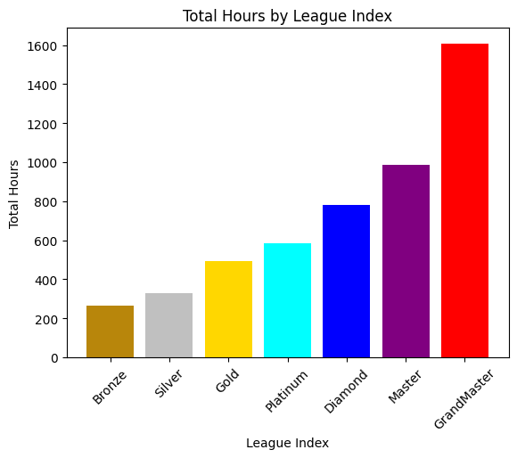

```python
#Call plot grouped data function for total hours
plot_grouped_data(filtered_df, 'LeagueIndex', 'TotalHours', league_labels, colors, 'Total Hours by League Index', 'League Index', 'Total Hours')
```

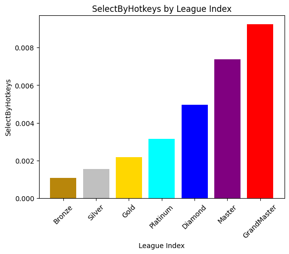

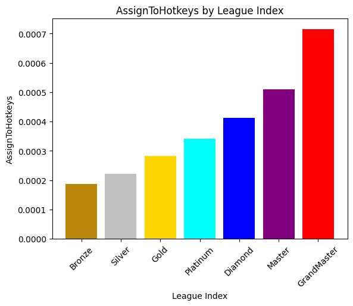

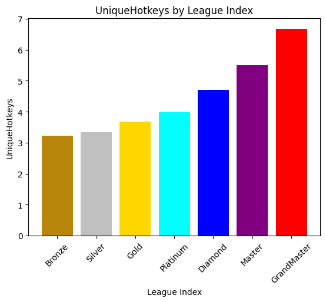

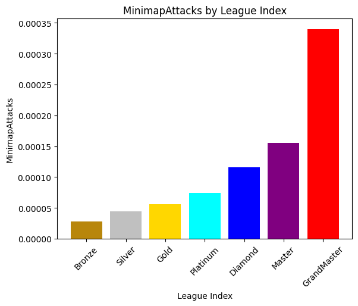

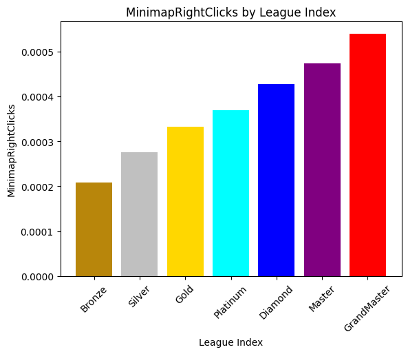

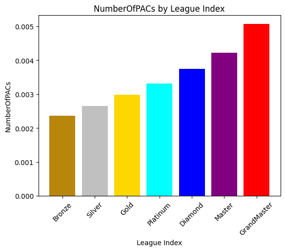

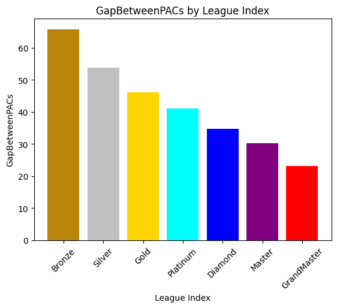

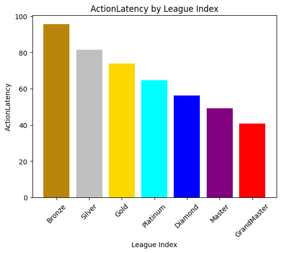

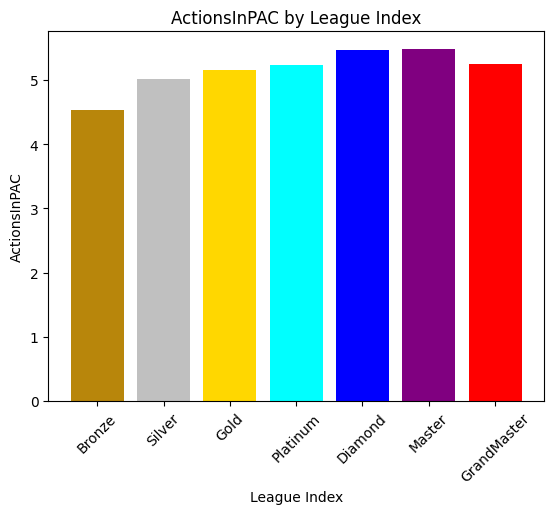

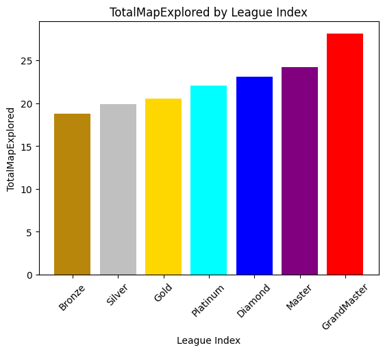

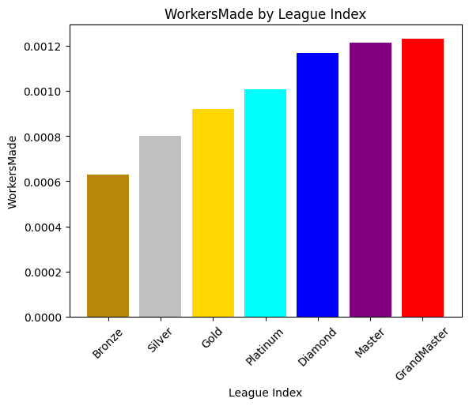

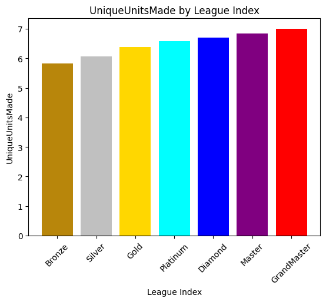

[2 more figures not shown]

```python
# Call plot_grouped_data function for each column
columns = ['SelectByHotkeys', 'AssignToHotkeys', 'UniqueHotkeys', 'MinimapAttacks', 'MinimapRightClicks',
           'NumberOfPACs', 'GapBetweenPACs', 'ActionLatency', 'ActionsInPAC', 'TotalMapExplored',
           'WorkersMade', 'UniqueUnitsMade', 'ComplexUnitsMade', 'ComplexAbilitiesUsed']

for column in columns:
    plot_grouped_data(filtered_df, 'LeagueIndex', column, league_labels, colors,
                      f'{column} by League Index', 'League Index', column)
```

# Hypothetical Scenario: Collecting More Data

After conducting exploratory data analysis (EDA), it is evident that professional games tend to have shorter durations compared to the rest of the player base. This can be observed from the difference in complex units made, which are typically associated with late-game strategies. The shorter game times in professional play are likely due to refined execution, the ability to capitalize on build order mistakes, and efficient use of workers and map exploration. To further investigate, gathering average game duration data is recommended.

Additionally, it is recommended to collect the last played ranked game date to ensure data relevance and alignment with the current meta. Analyzing trends among the different races (Protoss, Terran, Zerg) would provide valuable insights. Moreover, breaking down weekly hours based on various training activities, such as watching VODs, playing ranked games, practicing against easy AI for specific techniques (e.g., Elazer's creep spread), playing off-race, campaign, or arcade modes, would offer a comprehensive understanding of players' training habits and skill development. It is worth considering the longer queue times for higher-ranked players, which may lead them to use alternative accounts to find more opponents for practice.

In addition to APM (Actions Per Minute), capturing EPM (Effective Actions Per Minute) would be valuable. While they may be correlated, EPM focuses on the more meaningful actions a player performs during a game, whereas APM includes all actions, including spamming selection boxes.

Exploring the breakdown of unique camera locations set per game and their frequency of use could provide insights into the impact of this mechanic on rank. Understanding the struggles players face in setting camera locations and how it relates to their performance would be insightful.

Lastly, it would be interesting to include outliers such as maphackers in the data analysis to identify their patterns in EDA. It is expected that they would exhibit lower mechanics but higher ranks, which could provide valuable insights into identifying suspicious behavior.

Overall, expanding the data collection with these suggested variables would provide a more comprehensive understanding of player dynamics, strategies, and factors influencing rank.

I would have appreciated a PAC glossary for clarity during the assessment.

```python
# import ydata_profiling
# report = ydata_profiling.ProfileReport(filtered_df, title="Pandas Profiling Report")
# report
```

## I have created my own correlation map since the one provided by ydata_profiling has a color palette that is difficult to read. Ydata_profiling assisted me in EDA

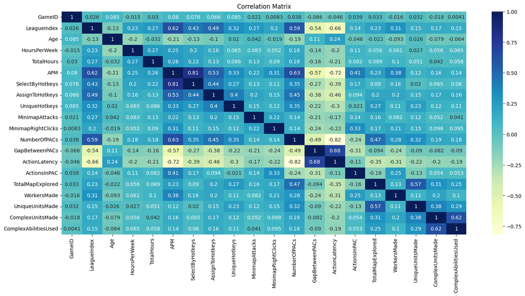

```python
# Explore correlations between features
correlation_matrix = filtered_df.corr()

# Plot correlation matrix heatmap
plt.figure(figsize=(18, 8))
sns.heatmap(correlation_matrix, annot=True, cmap="YlGnBu")
plt.title('Correlation Matrix')
plt.show()
```

```python
# Create a copy of the DataFrame
df_copy = filtered_df

# Separate the features (X) and target variable (y)
X = df_copy.drop(['LeagueIndex', 'GameID'], axis=1)
y = df_copy['LeagueIndex']

# Impute missing values with the mean
imputer = SimpleImputer(strategy='mean')
X_imputed = imputer.fit_transform(X)

# Perform standardization
scaler = StandardScaler()
X_scaled = scaler.fit_transform(X_imputed)

# Split the data into training and testing sets
X_train, X_test, y_train, y_test = train_test_split(X_scaled, y, test_size=0.2, random_state=42)

# Make predictions
new_data = pd.DataFrame({
    "Age": [25],
    "HoursPerWeek": [12],
    "TotalHours": [1500],
    "APM": [100],
    "SelectByHotkeys": [0.002],
    "AssignToHotkeys": [0.001],
    "UniqueHotkeys": [3],
    "MinimapAttacks": [0.001],
    "MinimapRightClicks": [0.001],
    "NumberOfPACs": [0.003],
    "GapBetweenPACs": [50],
    "ActionLatency": [70],
    "ActionsInPAC": [4],
    "TotalMapExplored": [30],
    "WorkersMade": [6],
    "UniqueUnitsMade": [7],
    "ComplexUnitsMade": [0],
    "ComplexAbilitiesUsed": [0.002]
})
```

```python
def evaluate_model(model, X_test, y_test, new_data):
    # Make predictions on the testing set
    y_pred = model.predict(X_test)

    # Evaluate accuracy
    accuracy = accuracy_score(y_test, y_pred)
    print("Accuracy:", accuracy)

    # Calculate MSE
    mse = mean_squared_error(y_test, y_pred)
    print("MSE:", mse)

    # Evaluate the model
    print(classification_report(y_test, y_pred, zero_division=1))

    # Predict the target variable for the new data
    predictions = model.predict(new_data)

    # Print the predictions
    print("Predictions:", predictions)

    return accuracy, mse, predictions
```

```python
# Create and train the logistic regression model
model_lr = LogisticRegression(max_iter=1000)
model_lr.fit(X_train, y_train)

# Make predictions on the testing set
y_pred = model_lr.predict(X_test)


# Get the feature names
feature_names = X.columns

# Retrieve the feature coefficients
coefficients = model_lr.coef_[0]
abs_coefficients_lr = np.abs(coefficients)

accuracy_lr, mse_lr, predictions_lr = evaluate_model(model_lr, X_test, y_test, new_data)
```

```
Accuracy: 0.4397590361445783
MSE: 1.0587349397590362
              precision    recall  f1-score   support

           1       0.36      0.41      0.38        22
           2       0.38      0.31      0.34        68
           3       0.34      0.30      0.32       100
           4       0.40      0.46      0.43       176
           5       0.47      0.45      0.46       170
           6       0.56      0.62      0.59       119
           7       0.50      0.11      0.18         9

    accuracy                           0.44       664
   macro avg       0.43      0.38      0.39       664
weighted avg       0.44      0.44      0.44       664

Predictions: [7]
```

```python
# Create the SVM model
svm_model = SVC()

# Fit the model to the training data
svm_model.fit(X_train, y_train)

# Make predictions on the testing data
y_pred = svm_model.predict(X_test)

# Calculate feature importances using permutation importance
perm_importance = permutation_importance(svm_model, X_test, y_test)

# Get feature importances
feature_importance_svm = perm_importance.importances_mean

accuracy_svm, mse_svm, predictions_svm = evaluate_model(svm_model, X_test, y_test, new_data)
```

```
Accuracy: 0.4292168674698795
MSE: 0.9939759036144579
              precision    recall  f1-score   support

           1       0.40      0.27      0.32        22
           2       0.36      0.22      0.27        68
           3       0.31      0.31      0.31       100
           4       0.42      0.54      0.47       176
           5       0.44      0.42      0.43       170
           6       0.56      0.56      0.56       119
           7       1.00      0.00      0.00         9

    accuracy                           0.43       664
   macro avg       0.50      0.33      0.34       664
weighted avg       0.43      0.43      0.42       664

Predictions: [5]
```

```python
# Create and fit the ordinal regression model
model_ord = LogisticAT()
model_ord.fit(X_train, y_train)

# Get feature importances
feature_importance_ord = perm_importance.importances_mean


accuracy_ordinal, mse_ordinal, predictions_ordinal = evaluate_model(model_ord, X_test, y_test, new_data)
```

```
Accuracy: 0.42319277108433734
MSE: 0.9728915662650602
              precision    recall  f1-score   support

           1       0.36      0.18      0.24        22
           2       0.30      0.21      0.24        68
           3       0.30      0.37      0.33       100
           4       0.41      0.49      0.45       176
           5       0.47      0.49      0.48       170
           6       0.61      0.47      0.53       119
           7       0.00      0.00      0.00         9

    accuracy                           0.42       664
   macro avg       0.35      0.32      0.33       664
weighted avg       0.43      0.42      0.42       664

Predictions: [7]
```

```python
# Train the Gradient Boosting model on the imputed data
model_gradient = GradientBoostingClassifier(loss="log_loss")
model_gradient.fit(X_train, y_train)

# Make predictions on the imputed test data
y_pred = model_gradient.predict(X_test)

# Retrieve the feature importance
feature_importance_gradient = model_gradient.feature_importances_

accuracy_gradient, mse_gradient, predictions_gradient = evaluate_model(model_gradient, X_test, y_test, new_data)
```

```
Accuracy: 0.40963855421686746
MSE: 1.1265060240963856
              precision    recall  f1-score   support

           1       0.31      0.41      0.35        22
           2       0.37      0.25      0.30        68
           3       0.33      0.37      0.35       100
           4       0.41      0.42      0.41       176
           5       0.45      0.45      0.45       170
           6       0.50      0.50      0.50       119
           7       0.00      0.00      0.00         9

    accuracy                           0.41       664
   macro avg       0.34      0.34      0.34       664
weighted avg       0.41      0.41      0.41       664

Predictions: [4]
```

```python
# Initialize the Random Forest regressor
rf = RandomForestRegressor(n_estimators=100, criterion='friedman_mse')

# Fit the model to the training data
rf.fit(X_train, y_train)

# Predict the target variable for the test set
y_pred = rf.predict(X_test)

# Convert regression problem to classification problem
y_pred_class = np.rint(y_pred).astype(int)

# Calculate accuracy
accuracy_rf = accuracy_score(y_test, y_pred_class)
print("Accuracy:", accuracy_rf)

# Evaluate the model
mse_rf = mean_squared_error(y_test, y_pred)
print("Mean Squared Error:", mse_rf)

# Predict the target variable for the new data
predictions = rf.predict(new_data)

# Print the predictions
print("Predictions:", predictions)

# Round the predictions to the nearest whole number
rounded_prediction = np.round(predictions).astype(int)

# Print the rounded predictions
print("Rounded Prediction:", rounded_prediction)

# Retrieve the feature importance
feature_importance_rf = rf.feature_importances_
```

```
Accuracy: 0.42018072289156627
Mean Squared Error: 0.7907871987951807
Predictions: [3.47]
Rounded Prediction: [3]
```

```python
# Define the neural network architecture
model_neural = Sequential()
model_neural.add(Dense(32, activation="relu", input_shape=(X_train.shape[1],)))
model_neural.add(Dense(16, activation="relu"))
model_neural.add(Dense(8, activation="relu"))
model_neural.add(Dense(1, activation="relu"))  # Changed activation function to "relu"

# Compile the model
model_neural.compile(loss="mean_squared_error", optimizer="adam")

# Train the model
model_neural.fit(X_train, y_train, epochs=100, batch_size=32, verbose=1)

# Convert regression problem to classification problem
y_pred_class = np.round(y_pred).astype(int)

# Calculate accuracy
accuracy_neural = accuracy_score(y_test, y_pred_class)
print("Accuracy:", accuracy_neural)

# Evaluate the model
mse_neural = model_neural.evaluate(X_test, y_test)
print("Mean Squared Error:", mse_neural)

# Calculate permutation importances
feature_names_neural = X.columns
importances = {}

for feature in feature_names:
    X_test_permuted = X_test.copy()
    np.random.shuffle(X_test_permuted[:, X.columns.get_loc(feature)])
    y_pred_permuted = model_neural.predict(X_test_permuted)
    permuted_mse = mean_squared_error(y_test, y_pred_permuted)
    importances[feature] = np.abs(mse_neural - permuted_mse)

feature_importance_neural = np.array(list(importances.values()))

# Predict the target variable for the new data
predictions = model_neural.predict(new_data)

# Print the predictions
print("Predictions:", predictions)
```

```
Accuracy: 0.42018072289156627
Mean Squared Error: 0.9148346185684204
Predictions: [[198.88232]]
```

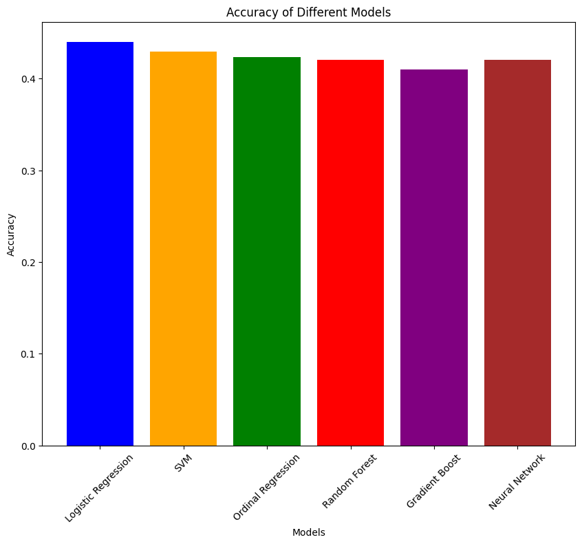

```python
# Create a list of model names
models = ['Logistic Regression', 'SVM', 'Ordinal Regression', 'Random Forest','Gradient Boost', 'Neural Network']

# Define colors for the bars
colors = ['blue', 'orange', 'green', 'red', 'purple', 'brown']


# Create a list of accuracy values
accuracy_values = [accuracy_lr, accuracy_svm, accuracy_ordinal, accuracy_rf, accuracy_gradient, accuracy_neural]

# Plot the accuracy values
plt.figure(figsize=(10, 8))
plt.bar(models, accuracy_values, color=colors)
plt.xlabel('Models')
plt.ylabel('Accuracy')
plt.title('Accuracy of Different Models')


# Rotate the x-axis labels
plt.xticks(rotation=45)
plt.show()
```

```
[1.0587349397590362, 0.9939759036144579, 0.9728915662650602, 0.7907871987951807, 1.1265060240963856, 0.9148346185684204]
```

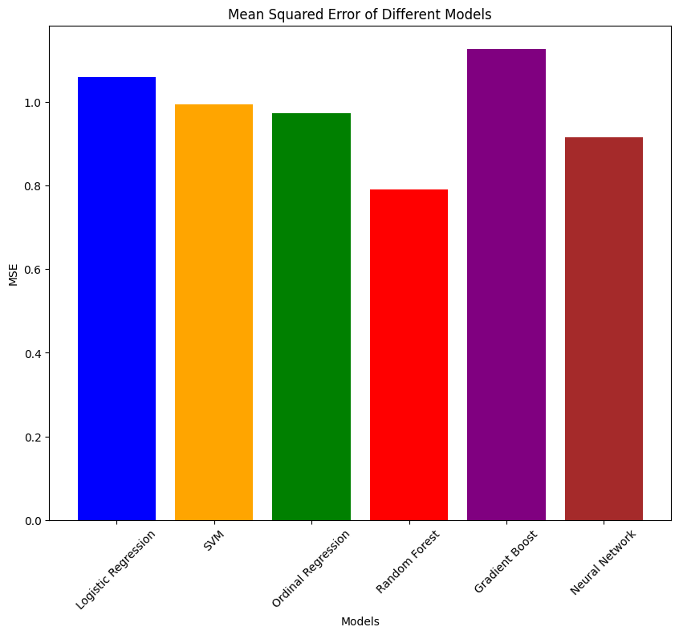

```python
# Create a list of MSE values
mse_values = [mse_lr, mse_svm, mse_ordinal, mse_rf, mse_gradient, mse_neural]

print(mse_values)

# Plot the MSE values
plt.figure(figsize=(10, 8))
plt.bar(models, mse_values, color=colors )
plt.xlabel('Models')
plt.ylabel('MSE')
plt.title('Mean Squared Error of Different Models')


# Rotate the x-axis labels
plt.xticks(rotation=45)
plt.show()
```